# assign non-target gopher-black-and-yellow rockfish with rubias

To start off with, let’s load data and libs:

```r
library(tidyverse)
library(CKMRsim)
library(stringr)
library(readxl)
#meta <- readRDS("../data/processed/meta-data-tibble.rds") # not worrying about meta data right now...
genos <- readRDS("../nsf_data/processed/called_genos_na_explicit.rds") #%>%
  #filter(NMFS_DNA_ID %in% meta$NMFS_DNA_ID)  # drop those we don't have meta data for
samples <- readRDS("../nsf_data/processed/sample-sheet-tibble.rds") #%>%
  #filter(NMFS_DNA_ID %in% meta$NMFS_DNA_ID)
```

## Some initial filters

### Take highest read-depth call for multiply-genotyped DNA_IDs

I’m not sure if there are any of these, but best to leave it in here… if an individual is multiply-genotyped, take the genotype with the highest total read depth.

```r
# slow-ish function to get the total read depth column
tdepth <- function(a, d) {
  if(any(is.na(a))) {
    return(NA)
  }
  if(a[1]==a[2]) {
    return(d[1])
  } else {
    return(d[1] + d[2])
  }

}
# this takes the highest read-depth instance of each duplicately-genotyped individual.
geno_one_each <- genos %>%
  group_by(NMFS_DNA_ID, locus, gtseq_run, id) %>%
  mutate(total_depth = tdepth(allele, depth)) %>%
  ungroup() %>%
  arrange(NMFS_DNA_ID, locus, total_depth, gtseq_run, id, depth) %>%
  group_by(NMFS_DNA_ID, locus) %>%
  mutate(rank = 1:n()) %>%
  ungroup() %>%
  filter(rank <= 2)
```

### Remove the 6 loci which Hayley has been removing

```r
# read in a list of the 6 loci
to_remove <- read_csv("../data/loci_to_remove.csv")
# only keep the loci that are not those 6
keepers <- geno_one_each %>%
  anti_join(., to_remove, by = "locus")
```

that should leave 90 loci

### Toss out indivs with data at fewer than 25 loci

Now, toss out any individual with fewer than 25 non-missing loci

```r
no_hi_missers <- keepers %>%
  group_by(NMFS_DNA_ID) %>%
  filter(sum(!is.na(allele)) >= (25*2))
```

## Read in baseline genotypes and remove loci and individuals with too much missing data

```r
# read in genotypes identified to species using rubias
spp <- read_csv("../data/reported_haplotype_SebSppID_11102017.csv")

select_spp <- spp %>%
  select(group, locus, indiv.ID, haplotype.1, haplotype.2)

spp.id <- select_spp %>%
  gather("gene_copy", "allele", 4:5) %>%
  mutate(gene_copy = ifelse(gene_copy == "haplotype.1", 1, 2))

# only keep the loci that are not the 6 removed from the previous dataset
spp.id_loc <- spp.id %>%
  anti_join(., to_remove, by = "locus")
# that should leave 90 loci
```

From the .csv output from microhaplot, we need to reform the data for rubias.

```r
# add reference column to prepare data for rubias
spp.id_loc1 <- spp.id_loc %>%
  mutate(sample_type = "reference")

# add the repunit column that is identical to the group in this case
x <- spp.id_loc1 %>%
  mutate(repunit = group)

# reorder the columns and get the data frame in the right format
spp.id1 <- x[,c(6,7,1,3,2,4:5)]
spp.id2 <- spp.id1 %>%
  rename(collection = group) %>%
  rename(indiv = indiv.ID)
```

To ensure that haplotypes are coded identically across both the reference and mixture genotypes, we need to combine the two data sets, and then change haplotypes into numeric alleles.

```r
# get the reference and mixture data frames into the same format
no_hi_missers2 <- no_hi_missers %>%
  dplyr::select(NMFS_DNA_ID, locus, gene_copy, allele) %>%
  rename(indiv = NMFS_DNA_ID) %>%
  mutate(sample_type = "mixture") %>%
  mutate(repunit = NA) %>%
  mutate(collection = "nsf_samples")

# reorder the columns for the mixture data frame
no_hi_missers3 <- no_hi_missers2[, c(5:7,1:4)]

# combine both data sets into a single df
alleles <- bind_rows(spp.id2, no_hi_missers3)
```

Here we turn alleles into integers, spread the data frame, and then get it into the right format to run rubias:

```r
# first make integers of the alleles
alle_idxs <- alleles %>%
  #dplyr::select(NMFS_DNA_ID, locus, gene_copy, allele) %>%
  group_by(locus) %>%
  mutate(alleidx = as.integer(factor(allele, levels = unique(allele)))) %>%
  ungroup() %>%
  arrange(indiv, locus, alleidx) # rubias can handle NA's, so no need to change them to 0's

# select just the columns to retain and spread the alleles
alle_idx2 <- alle_idxs[,-7]

two_col <- alle_idx2 %>%
  unite(loc, locus, gene_copy, sep = ".") %>%
  spread(loc, alleidx)

# write this file to a thing that can be read-into other softwares
#two_col %>%
# write_csv("csv_outputs/genos_two_col.csv")
```

I’ll split the data frame that I created (but it needed to be bunged together for the conversion of alleles to integers).

```r
# split up the reference and mixture data frames
sp_mix <- two_col %>%
  filter(sample_type == "mixture")

sp_ref <- two_col %>%
  filter(sample_type == "reference")
```

[output not shown]

[output cut: 10 more lines]

The posterior means of group membership in each collection is in the PofZ column.

Make a quick little plot to display the diversity of species in our NSF juvenile samples.

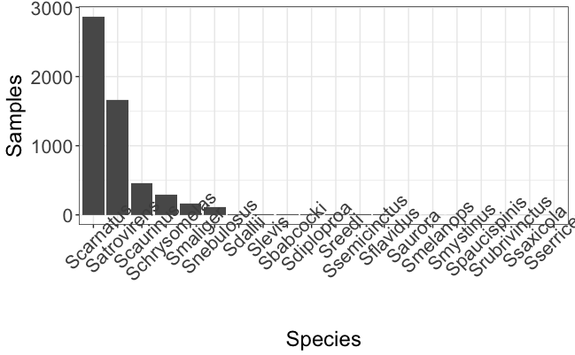

```r
# ordered by number of samples
ggplot(grp_tally, (aes(x = reorder(repunit, -n), y = n))) +
  geom_bar(stat = "identity") +
  theme_bw() +
  ylab("Samples") +
  xlab("Species") +
  theme(
    axis.text.x = element_text(angle = 45, size = 16),
    axis.text.y = element_text(size = 16),
    axis.title = element_text(size = 18)) +
  scale_color_brewer(palette = "Set1")

ggsave("pdf_outputs/nsf_juv_id.pdf", height = 7, width = 12)
```

[figure not shown]

```r
# There are individual assignments for each sample to each reference.
# If I want to keep the top assignment for each sample:
kept_assignments <- mix_assign$indiv_posteriors %>%
  group_by(indiv) %>%
  filter(PofZ > 0.5) %>%
  arrange(desc(PofZ))

kept_assignments
```

[output not shown]